# Praca domowa 2

Wojciech Florek

## Dane

Dane wykorzystane w Pracy domowej 2 dotyczą wyników egzaminów z 3 umiejętności: czytania, pisania i operacji matematycznych. Dodatkowo dostępne są podstawowe informacje o studentach i ich rodzicach. Opis wszystkich kolumn znajduje się również w pliku `README.md`.

| Zmienna | Opis |
| --- | --- |
| **gender** | płeć |
| **race.ethnicity** | pochodzenie etniczne |
| **parental.level.of.education** | wykształcenie rodziców |
| **lunch** | jaki obiad jedli uczniowie w dniu egzaminu |
| **test.preparation.course** | czy uczeń odbył kurs przygotowujący |
| **math.score** | wynik egzaminu z matematyki |
| **reading.score** | wynik egzaminu z czytania |
| **writing.score** | wynik egzaminu z pisania |

## Zadanie 1

Jak wyglądają rozkłady wyników uczniów z trzech przedmiotów (matematyka, czytanie, pisanie)?

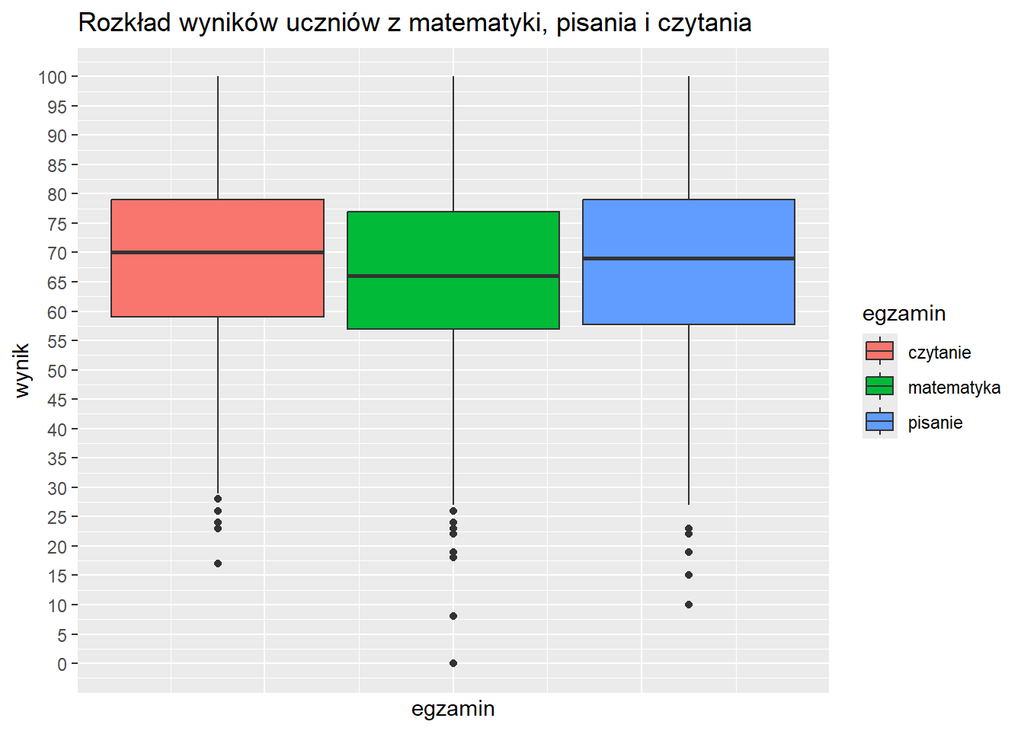

```r
wynik1 <- df %>%
  select(matematyka=math.score,czytanie=reading.score,pisanie=writing.score) %>%
  pivot_longer(cols=c(matematyka,czytanie,pisanie),names_to="egzamin",values_to="wynik")

wynik1 %>%
  ggplot(aes(y=wynik,fill=egzamin))+
  geom_boxplot()+
  labs(title="Rozkład wyników uczniów z matematyki, pisania i czytania",x="egzamin")+
  theme(axis.text.x = element_blank(),axis.ticks.x = element_blank())+
  scale_y_continuous(breaks = seq(0, 100, by = 5))
```

**Komentarz: Widać względnie podobne rozkłady (patrząc na prostokąty), lecz najlepiej uczniom idzie w czytaniu, a najgorzej w matematyce**

## Zadanie 2

Czy istnieje zauważalna różnica w wynikach między uczniami i uczennicami?

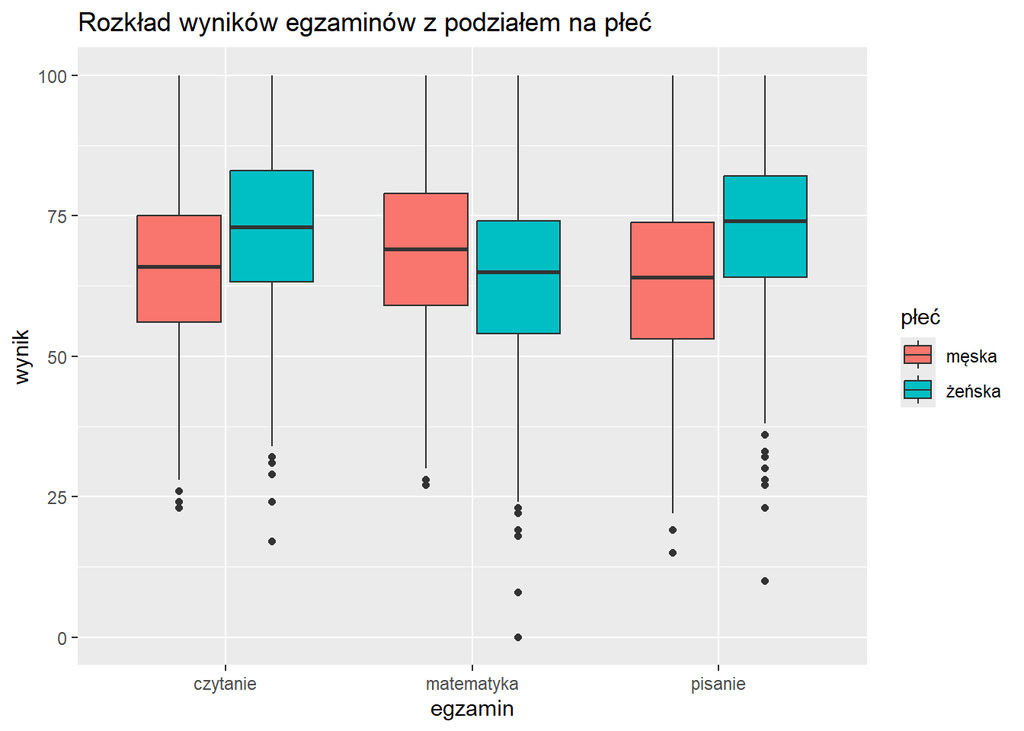

```r
wynik2 <- df %>%
  select(płeć=gender,matematyka=math.score,czytanie=reading.score,pisanie=writing.score) %>%
  group_by(płeć) %>%
  mutate(płeć = factor(płeć,levels = c("male","female"),labels = c("męska","żeńska"))) %>%
  pivot_longer(cols=c(matematyka,czytanie,pisanie),names_to="egzamin",values_to="wynik")

wynik2 %>%
  ggplot(aes(x=egzamin,y=wynik,fill=płeć))+
  geom_boxplot()+
  labs(title="Rozkład wyników egzaminów z podziałem na płeć")
```

**Komentarz: Tak, uczniom idzie lepiej w matematyce, a uczennicom w czytaniu i pisaniu**

## Zadanie 3

Czy uczniowie, którzy ukończyli kurs przygotowawczy, osiągają lepsze wyniki niż pozostali?

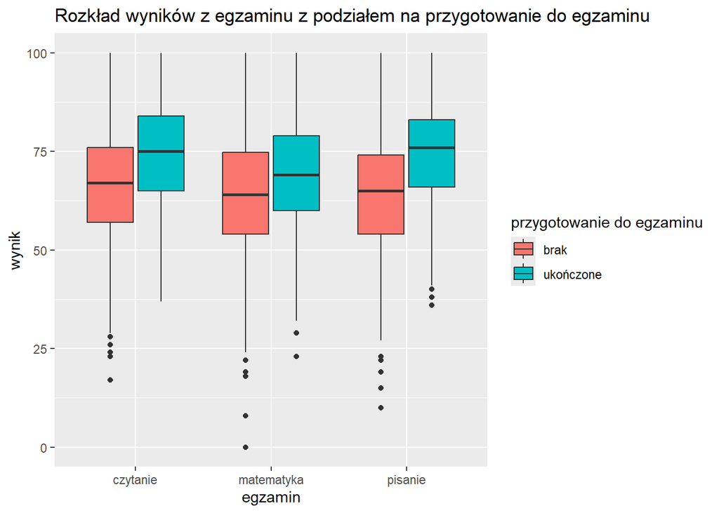

```r
wynik3 <- df %>%
  select(przygotowanie_do_egzaminu=test.preparation.course,matematyka=math.score,czytanie=reading.score,pisanie=writing.score) %>%
  group_by(przygotowanie_do_egzaminu) %>%
  mutate(przygotowanie_do_egzaminu = factor(przygotowanie_do_egzaminu,levels = c("none","completed"),labels = c("brak","ukończone"))) %>%
  pivot_longer(cols=c(matematyka,czytanie,pisanie),names_to="egzamin",values_to = "wynik")

wynik3 %>%
  ggplot(aes(x=egzamin,y=wynik,fill=przygotowanie_do_egzaminu))+
  geom_boxplot()+
  labs(title="Rozkład wyników z egzaminu z podziałem na przygotowanie do egzaminu",fill="przygotowanie do egzaminu")
```

**Komentarz: Tak, uczniowie, którzy mieli ukończony kurs przygotowawczy mieli lepsze wyniki niż ci, którzy tego kursu nie ukończyli**

## Zadanie 4

Jaki jest związek między poziomem wykształcenia rodziców a średnimi wynikami uczniów?

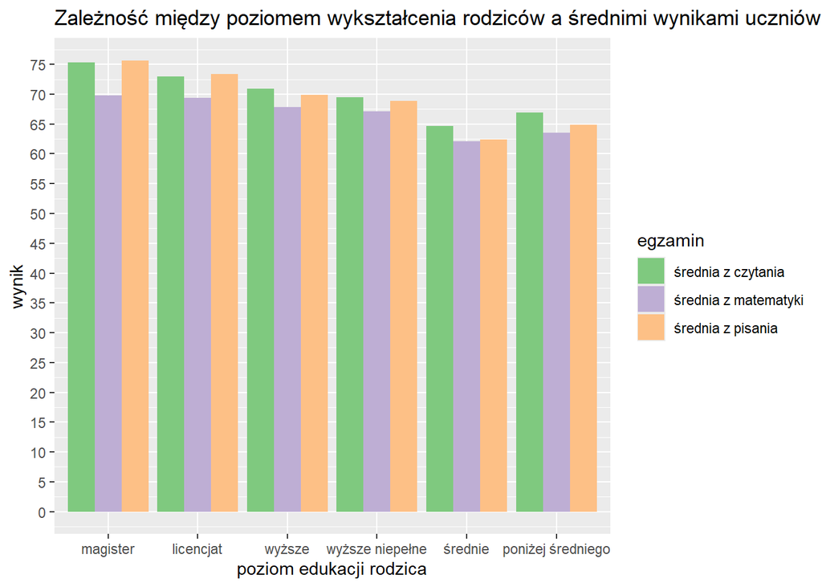

```r
wynik4 <- df %>%
  select(poziom_edukacji_rodzica=parental.level.of.education,matematyka=math.score,czytanie=reading.score,pisanie=writing.score) %>%
  group_by(poziom_edukacji_rodzica) %>%
  summarise("średnia z matematyki"=mean(matematyka),"średnia z czytania"=mean(czytanie),"średnia z pisania"=mean(pisanie)) %>%
    pivot_longer(cols=c("średnia z matematyki","średnia z czytania","średnia z pisania"),names_to = "egzamin",values_to = "wynik") %>%
  mutate(poziom_edukacji_rodzica = factor(poziom_edukacji_rodzica,levels = c("master's degree","bachelor's degree","associate's degree","some college","high school","some high school"),labels = c("magister","licencjat","wyższe","wyższe niepełne","średnie","poniżej średniego")))#associate's degree to jakiś wyższy poziom edukacji poniżej licencjata nie istniejący w polsce

wynik4 %>%
  ggplot(aes(x=poziom_edukacji_rodzica,y=wynik,fill=egzamin))+
  geom_col(position = "dodge")+
  labs(title="Zależność między poziomem wykształcenia rodziców a średnimi wynikami uczniów",x="poziom edukacji rodzica")+
  scale_fill_manual(values = c("średnia z czytania" = "#7fc97f", "średnia z matematyki" = "#beaed4","średnia z pisania" = "#fdc086"))+#ze strony colorbewer
  scale_y_continuous(breaks = seq(0, 100, by = 5))
```

**Komentarz: Im większy poziom wykształcenia rodziców, tym większa średnia z egzaminu, za wyjątkiem rodziców którzy ukończyli liceum (zamiast przedostatniego miejsca są na ostatnim)**

## Zadanie 5

Czy płeć i wykształcenie rodzica wpływa na wynik z matematyki?

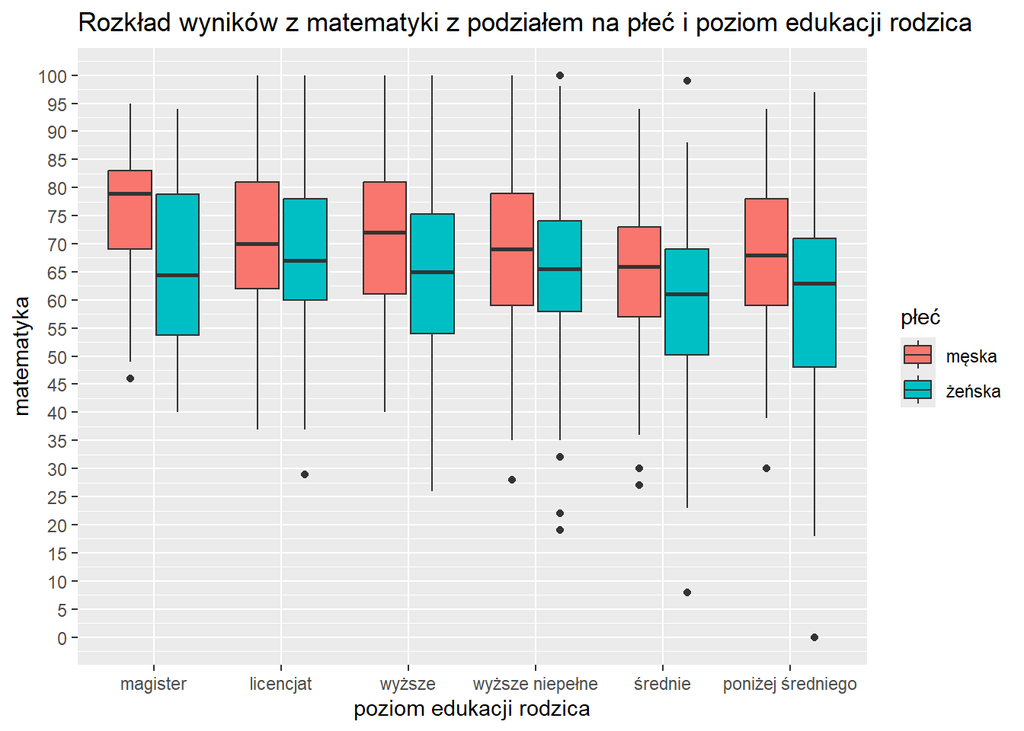

```r
wynik5 <- df %>%
  select(płeć=gender,poziom_edukacji_rodzica=parental.level.of.education,matematyka=math.score) %>%
  mutate(płeć = factor(płeć,levels = c("male","female"),labels = c("męska","żeńska"))) %>%
  mutate(poziom_edukacji_rodzica = factor(poziom_edukacji_rodzica,levels = c("master's degree","bachelor's degree","associate's degree","some college","high school","some high school"),labels = c("magister","licencjat","wyższe","wyższe niepełne","średnie","poniżej średniego")))


wynik5 %>%
  ggplot(aes(x=poziom_edukacji_rodzica,fill=płeć,y=matematyka))+
  geom_boxplot()+
  labs(title="Rozkład wyników z matematyki z podziałem na płeć i poziom edukacji rodzica",x="poziom edukacji rodzica")+
  scale_y_continuous(breaks = seq(0,100,by=5))
```

**Komentarz: Tak, mamy względnie podobne wnioski jak w zadaniu 2 i 4 (z wyjątkiem rodziców licencjatów u uczniów i rodziców magistrów u uczennic)**

## Zadanie 6

Czy istnieje zależność między wynikami z matematyki a wynikami z czytania lub pisania?

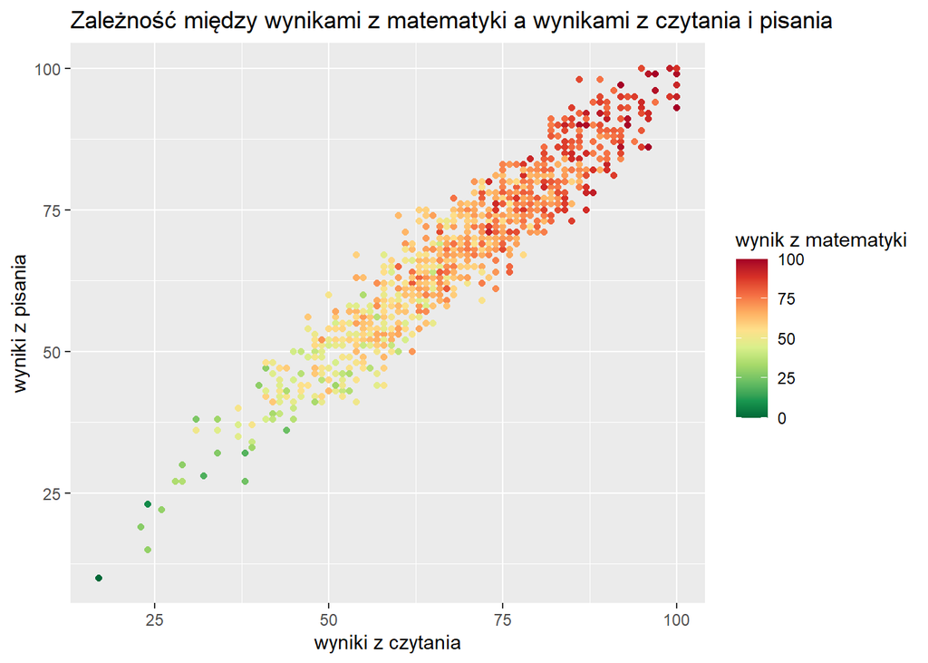

```r
wynik6 <- df %>%
  select(matematyka=math.score,czytanie=reading.score,pisanie=writing.score)

wynik6 %>%
  ggplot(aes(x=czytanie,y=pisanie,colour=matematyka))+
  geom_point()+
  scale_color_gradientn(colors=c("#006837","#1a9850","#66bd63","#a6d96a","#d9ef8b","#fee08b","#fdae61","#f46d43","#d73027","#a50026"))+#ze strony colorbewer
  labs(title="Zależność między wynikami z matematyki a wynikami z czytania i pisania",x="wyniki z czytania",y="wyniki z pisania",color="wynik z matematyki")
```

**Komentarz: Tak, im wyższy wynik z matematyki tym względnie wyższe wyniki z czytania i pisania**